# answers

## Answers

Run the `piplite` cell only if you're on JupyterLite.

### NumPy puzzle 1

#### Solution

Either keep the number of dimensions intact (the first dimension has length 1):

```
array([[[ 2,  3,  4],
        [ 7,  8,  9],
        [12, 13, 14]]])
```

or reduce that dimension:

```
array([[ 2,  3,  4],
       [ 7,  8,  9],
       [12, 13, 14]])
```

These are different answers to the question, but both are fine.

### NumPy puzzle 2

#### Solution

This involves slicing and applying a [universal function](https://numpy.org/doc/stable/reference/ufuncs.html) across all elements, showing how NumPy's elementary operations can be combined to get functionality that wasn't explicitly compiled into the library.

```
array([1.1, 1.1, 1.1, 1.1, 1.1, 1.1, 1.1, 1.1])
```

### NumPy puzzle 3

#### Solution

This calculation of path length involves slicing, universal functions, and reduction.

```
9564.961050220914
```

### NumPy puzzle 4

#### Solution

In NumPy, the shapes of arrays are fluid. An array can be reshaped from 3 dimensional to 5 dimensional as long as the number of items is unchanged.

Reshaping provides new axes for reducers like [np.mean](https://numpy.org/doc/stable/reference/generated/numpy.mean.html) to apply.

Be sure to average over axis 3 before axis 1, since reduction removes an axis, changing the numbering of later axes.

Or alternatively, use negative axis numbers and do it in the other order.

Or as a third option, use `keepdims=True` to keep the axis numbering from changing and only remove the length 1 dimensions after all reductions are done.

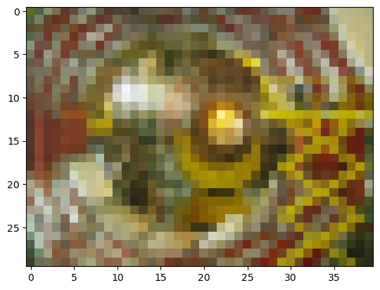

### NumPy puzzle 5

#### Solution

This is similar to the image-scaling puzzle: we use short-lived axes to be able to express an operation, but instead of reduction, it's a direction-reversing slice. Without reshaping, we wouldn't be able to express "groups of 4."

```
array([ 9.831079 , 12.383099 , 12.991788 , ...,  4.3587666,  5.632667 ,
        4.7507796], dtype=float32)
```

### Awkward puzzle 1

#### Solution

In NumPy puzzle 2, you subtracted each element from its neighbor by slicing `array[1:]` (drops the first) and `array[:-1]` (drops the last) before subtracting.

Here, you can do something similar, but it has to apply to the particles axis, not the events axis, so

```
[[True, True],
 [],
 [],
 [True, False, True, False, False, True],
 [],
 [False],
 [],
 [],
 [],
 [],
 ...,
 [False],
 [True],
 [False],
 [],
 [False],
 [False],
 [False, False, True],
 [],
 []]
-----------------------------------------
type: 299973 * var * bool
```

(either subtract and compare with zero or just compare one to the next).

We want to know if it's always true that `dataset.Muon_pt[:, :-1] > dataset.Muon_pt[:, 1:]`. We can see by eye that there are some `False` values above, but we can clinch it by

```
False
```

It is not true that the muon $p_T$ values are sorted within each event.

The consequence, for this dataset, is that `dataset.Muon_pt[:, 0]` is not the leading $p_T$ and `0` and `1` are not necessarily the two most relevant muons.

### Awkward puzzle 2

#### Solution 1

Take an event if "any muon $p_T > 50$ GeV (considering all particles)."

```
[True,
 False,
 False,
 True,
 False,
 False,
 False,
 False,
 False,
 False,
 ...,
 True,
 False,
 True,
 False,
 False,
 False,
 False,
 False,
 False]
-------------------
type: 299973 * bool
```

#### Solution 2

Take an event if "the maximum muon $p_T$ (over all particles) $> 50$ GeV."

```
[True,
 None,
 None,
 True,
 None,
 False,
 False,
 None,
 None,
 None,
 ...,
 True,
 False,
 True,
 None,
 False,
 False,
 False,
 None,
 None]
--------------------
type: 299973 * ?bool
```

Some of these boolean values are missing because there is no maximum of an empty list, and that missing value (`None`) results in a missing conclusion about whether it is greater than 50 GeV or not.

The missing values can be converted into `False` with [ak.fill_none](https://awkward-array.org/doc/main/reference/generated/ak.fill_none.html)

```
[True,
 False,
 False,
 True,
 False,
 False,
 False,
 False,
 False,
 False,
 ...,
 True,
 False,
 True,
 False,
 False,
 False,
 False,
 False,
 False]
-------------------
type: 299973 * bool
```

#### Solution 3

Take an event if "the number of muons that have $p_T > 50$ GeV is $\ge 1$."

```
[True,
 False,
 False,
 True,
 False,
 False,
 False,
 False,
 False,
 False,
 ...,
 True,
 False,
 True,
 False,
 False,
 False,
 False,
 False,
 False]
-------------------
type: 299973 * bool
```

#### Solution 4

Take an event if "the number of muons in which '$p_T > 50$ GeV' is true (not zero) $\ge 1$."

```
[True,
 False,
 False,
 True,
 False,
 False,
 False,
 False,
 False,
 False,
 ...,
 True,
 False,
 True,
 False,
 False,
 False,
 False,
 False,
 False]
-------------------
type: 299973 * bool
```

#### Solution 5

Take an event if "the sum of 'muon $p_T > 50$ GeV' (false = 0, true = 1) over particles is $\ge 1$."

```
[True,
 False,
 False,
 True,
 False,
 False,
 False,
 False,
 False,
 False,
 ...,
 True,
 False,
 True,
 False,
 False,
 False,
 False,
 False,
 False]
-------------------
type: 299973 * bool
```

#### Application

Apply it to the `dataset` as a slice. You get whole events (all fields) back.

```
[{run: 1, luminosityBlock: 156, event: 46501, PV_npvs: 15, PV_x: 0.244, ...},
 {run: 1, luminosityBlock: 156, event: 46504, PV_npvs: 22, PV_x: 0.243, ...},
 {run: 1, luminosityBlock: 156, event: 46512, PV_npvs: 10, PV_x: 0.243, ...},
 {run: 1, luminosityBlock: 156, event: 46524, PV_npvs: 14, PV_x: 0.243, ...},
 {run: 1, luminosityBlock: 156, event: 46526, PV_npvs: 14, PV_x: 0.244, ...},
 {run: 1, luminosityBlock: 156, event: 46530, PV_npvs: 15, PV_x: 0.244, ...},
 {run: 1, luminosityBlock: 156, event: 46536, PV_npvs: 23, PV_x: 0.247, ...},
 {run: 1, luminosityBlock: 156, event: 46539, PV_npvs: 20, PV_x: 0.242, ...},
 {run: 1, luminosityBlock: 156, event: 46547, PV_npvs: 20, PV_x: 0.243, ...},
 {run: 1, luminosityBlock: 156, event: 46554, PV_npvs: 10, PV_x: 0.242, ...},
 ...,
 {run: 1, luminosityBlock: 996, event: 298698, PV_npvs: 27, PV_x: 0.244, ...},
 {run: 1, luminosityBlock: 996, event: 298703, PV_npvs: 12, PV_x: 0.242, ...},
 {run: 1, luminosityBlock: 996, event: 298710, PV_npvs: 30, PV_x: 0.245, ...},
 {run: 1, luminosityBlock: 996, event: 298726, PV_npvs: 20, PV_x: 0.244, ...},
 {run: 1, luminosityBlock: 996, event: 298759, PV_npvs: 29, PV_x: 0.247, ...},
 {run: 1, luminosityBlock: 996, event: 298760, PV_npvs: 11, PV_x: 0.245, ...},
 {run: 1, luminosityBlock: 996, event: 298781, PV_npvs: 16, PV_x: 0.243, ...},
 {run: 1, luminosityBlock: 996, event: 298792, PV_npvs: 24, PV_x: 0.244, ...},
 {run: 1, luminosityBlock: 996, event: 298794, PV_npvs: 24, PV_x: 0.245, ...}]
------------------------------------------------------------------------------
type: 37410 * {
    run: int32,
    luminosityBlock: uint32,
    event: uint64,
    PV_npvs: int32,
    PV_x: float32,
    PV_y: float32,
    PV_z: float32,
    nMuon: uint32,
    Muon_pt: var * float32,
    Muon_eta: var * float32,
    Muon_phi: var * float32,
    Muon_mass: var * float32,
    Muon_charge: var * int32,
    Muon_pfRelIso03_all: var * float32,
    Muon_pfRelIso04_all: var * float32,
    Muon_dxy: var * float32,
    Muon_dxyErr: var * float32,
    Muon_dz: var * float32,
    Muon_dzErr: var * float32,
    nElectron: uint32,
    Electron_pt: var * float32,
    Electron_eta: var * float32,
    Electron_phi: var * float32,
    Electron_mass: var * float32,
    Electron_charge: var * int32,
    Electron_pfRelIso03_all: var * float32,
    Electron_dxy: var * float32,
    Electron_dxyErr: var * float32,
    Electron_dz: var * float32,
    Electron_dzErr: var * float32,
    MET_pt: float32,
    MET_phi: float32
}
```

Notice that the total number of events is lower, which is not the case for a particle cut.

### Awkward puzzle 3

#### Solution

This answer can have the same variety as puzzle 2 because it asks for *any* particle satisfying a condition, as above.

```
[False,
 False,
 False,
 True,
 False,
 True,
 False,
 False,
 False,
 False,
 ...,
 True,
 True,
 False,
 False,
 False,
 True,
 False,
 False,
 False]
-------------------
type: 299973 * bool
```

### Awkward puzzle 4

#### Solution

You can use [ak.num](https://awkward-array.org/doc/main/reference/generated/ak.num.html) or the `nMuon` field of the `dataset`.

Remember that the first axis is `EVENT` and we want all of them, so select `:`, then the second axis is `PARTICLE`.

```
[38.5,
 27.4,
 43.4,
 12.3,
 39.6,
 67.7,
 47.4,
 43.8,
 16.7,
 18.2,
 ...,
 23.3,
 8.73,
 23.8,
 39.3,
 37.2,
 43.2,
 24.2,
 9.81,
 32.6]
---------------------
type: 85838 * float32
```

```
[47,
 67.7,
 43.2,
 7.91,
 3.7,
 12.3,
 31.3,
 3.28,
 6.12,
 11.3,
 ...,
 12.2,
 22.1,
 3.47,
 9.87,
 50.1,
 24,
 79.5,
 25.5,
 43.1]
---------------------
type: 85838 * float32
```

### Awkward puzzle 5

#### Solution

```
[87.1,
 90.5,
 89.2,
 18.8,
 4.59,
 37.2,
 90.6,
 8.91,
 18.1,
 27.5,
 ...,
 31.2,
 0.762,
 14.3,
 90.7,
 90,
 88.6,
 88.8,
 27.9,
 90.5]
---------------------
type: 85838 * float32
```

Regular(100, 0, 100, label='mass (GeV)')

Double() Σ=85540.0 *(85838.0 with flow)*

### Awkward puzzle 6

#### Solution

Regular(100, 0, 100, label='mass GeV')

Double() Σ=271500.0 *(272832.0 with flow)*

### Awkward puzzle 7

#### Solution 1

One way, by combining pairs of pairs:

```
[[],
 [],
 [],
 [],
 [],
 [],
 [],
 [],
 [],
 [],
 ...,
 [(({pt: ..., ...}, {...}), ({...}, {...}))],
 [],
 [],
 [],
 [],
 [],
 [],
 [],
 []]
---------------------------------------------
type: 299973 * var * (
    (
        Momentum4D[
            pt: float32,
            phi: float32,
            eta: float32,
            mass: float32,
            charge: int32
        ],
        Momentum4D[
            pt: float32,
            phi: float32,
            eta: float32,
            mass: float32,
            charge: int32
        ]
    ),
    (
        Momentum4D[
            pt: float32,
            phi: float32,
            eta: float32,
            mass: float32,
            charge: int32
        ],
        Momentum4D[
            pt: float32,
            phi: float32,
            eta: float32,
            mass: float32,
            charge: int32
        ]
    )
)
```

These could be pulled apart with [ak.unzip](https://awkward-array.org/doc/main/reference/generated/ak.unzip.html), but because the tuples are nested within tuples, it's a little easier to access them by direct address.

`"0"` gets the first field (and `"1"` gets the second field) of *every tuple in an array*. This is very different from selecting `0` and `1` without quotes.

Regular(150, 0, 150, label='Axis 0')

Double() Σ=59705.0 *(63945.0 with flow)*

#### Solution 2

But if we don't need to address the dimuons and dielectrons directly (to perform cuts on them), we could just use [ak.cartesian](https://awkward-array.org/doc/main/reference/generated/ak.cartesian.html) to make quadruples directly.

```
[[],
 [],
 [],
 [],
 [],
 [],
 [],
 [],
 [],
 [],
 ...,
 [({pt: 50.1, phi: 2.65, ...}, {pt: 37.2, ...}, {...}, {...})],
 [],
 [],
 [],
 [],
 [],
 [],
 [],
 []]
---------------------------------------------------------------
type: 299973 * var * (
    Momentum4D[
        pt: float32,
        phi: float32,
        eta: float32,
        mass: float32,
        charge: int32
    ],
    Momentum4D[
        pt: float32,
        phi: float32,
        eta: float32,
        mass: float32,
        charge: int32
    ],
    Momentum4D[
        pt: float32,
        phi: float32,
        eta: float32,
        mass: float32,
        charge: int32
    ],
    Momentum4D[
        pt: float32,
        phi: float32,
        eta: float32,
        mass: float32,
        charge: int32
    ]
)
```

Doing it this way, they're not nested, and one [ak.unzip](https://awkward-array.org/doc/main/reference/generated/ak.unzip.html) will pull them apart.

Regular(150, 0, 150, label='Axis 0')

Double() Σ=59705.0 *(63945.0 with flow)*

### Awkward puzzle 8

#### Solution

Regular(150, 0, 150, label='Axis 0')

Double() Σ=292303.0 *(314907.0 with flow)*

### Awkward puzzle 9

#### Solution

```
[[],
 [None, None, None, None],
 [None, None],
 [{pt: 23.5, phi: -0.307, eta: -0.248, mass: 0.106, charge: -1}],
 [None, None, None, None],
 [{pt: 47, phi: -1.15, eta: -0.119, mass: 0.106, charge: 1}],
 [{pt: 4.45, phi: 1.12, eta: -0.986, mass: 0.106, charge: 1}],
 [None],
 [None, None, None, None],
 [],
 ...,
 [{pt: 37.2, phi: -0.875, eta: 1.1, mass: 0.106, charge: -1}, {...}],
 [{pt: 24, phi: 1.38, eta: 0.421, mass: 0.106, charge: -1}],
 [],
 [None, None, None],
 [],
 [{pt: 43.1, phi: 2.27, eta: -0.162, mass: 0.106, charge: -1}],
 [],
 [None, None],
 [None, None]]
---------------------------------------------------------------------
type: 299973 * var * ?Momentum4D[
    pt: float32,
    phi: float32,
    eta: float32,
    mass: float32,
    charge: int32
]
```